```python
import pandas as pd
import numpy as np
import seaborn as sns
import matplotlib.pyplot as plt
import plotly.figure_factory as ff
from scipy import stats
from sklearn.model_selection import train_test_split
from sklearn.discriminant_analysis import LinearDiscriminantAnalysis
from sklearn.metrics import accuracy_score
```

```python
hr_data = pd.read_csv('/Users/mac/Downloads/HR (1).csv')
hr_data.head()
```

|  | satisfaction_level | last_evaluation | number_project | average_montly_hours | time_spend_company | Work_accident | left | promotion_last_5years | department | salary |
| --- | --- | --- | --- | --- | --- | --- | --- | --- | --- | --- |
| 0 | 0.38 | 0.53 | 2 | 157 | 3 | 0 | 1 | 0 | sales | low |
| 1 | 0.80 | 0.86 | 5 | 262 | 6 | 0 | 1 | 0 | sales | medium |
| 2 | 0.11 | 0.88 | 7 | 272 | 4 | 0 | 1 | 0 | sales | medium |
| 3 | 0.72 | 0.87 | 5 | 223 | 5 | 0 | 1 | 0 | sales | low |
| 4 | 0.37 | 0.52 | 2 | 159 | 3 | 0 | 1 | 0 | sales | low |

# Задание 2

Рассчитайте основные статистики для переменных (среднее,медиана,мода,мин/макс,сред.отклонение).

```python
#общая статистика, переделала для удобного формата. Здесь указаны пустые значения, уникальные и общее количество.
data = pd.DataFrame()
data['uniq'] = hr_data.nunique()
data['with null'] = hr_data.isna().sum()
data['count'] = hr_data.count() - data['with null']
dtypes = hr_data.dtypes
data['type'] = dtypes
data
```

|  | uniq | with null | count | type |
| --- | --- | --- | --- | --- |
| satisfaction_level | 92 | 0 | 14999 | float64 |
| last_evaluation | 65 | 0 | 14999 | float64 |
| number_project | 6 | 0 | 14999 | int64 |
| average_montly_hours | 215 | 0 | 14999 | int64 |
| time_spend_company | 8 | 0 | 14999 | int64 |
| Work_accident | 2 | 0 | 14999 | int64 |
| left | 2 | 0 | 14999 | int64 |
| promotion_last_5years | 2 | 0 | 14999 | int64 |
| department | 10 | 0 | 14999 | object |
| salary | 3 | 0 | 14999 | object |

```python
#решила еще посмотреть количество дублей
duplicate_rows = hr_data.duplicated().sum()
print(f"Number of duplicate rows: {duplicate_rows}")
```

```
Number of duplicate rows: 3008
```

Пустых значений нет. Так как satisfaction_level, last_evaluation, average_montly_hours много уникальных значений решаю проверять являются ли они неприрывными величинами.

Также из описания к датасету и датасета непостредственно мы можем понять, что к категориальным величинам у нас относятся Work_accident, left, promotion_last_5years, department, salary Остальные количественные

```python
for col in hr_data.columns.values:
    if (len(hr_data[col].value_counts())> 5) and (hr_data[col].isnull().sum() > 0):
      print(col)

#нет, если бы являлись, то в результате работы кода их имена были бы в списке
```

Тогда я подумала, что такое количество дублей это ошибка датафрейма. Так как каждая строка это уникальный сотрудник, то не может быть такое повторение внутри датасета

```python
hr_data = hr_data.drop_duplicates().reset_index(drop=True)
hr_data.head(5)
```

|  | satisfaction_level | last_evaluation | number_project | average_montly_hours | time_spend_company | Work_accident | left | promotion_last_5years | department | salary |
| --- | --- | --- | --- | --- | --- | --- | --- | --- | --- | --- |
| 0 | 0.38 | 0.53 | 2 | 157 | 3 | 0 | 1 | 0 | sales | low |
| 1 | 0.80 | 0.86 | 5 | 262 | 6 | 0 | 1 | 0 | sales | medium |
| 2 | 0.11 | 0.88 | 7 | 272 | 4 | 0 | 1 | 0 | sales | medium |
| 3 | 0.72 | 0.87 | 5 | 223 | 5 | 0 | 1 | 0 | sales | low |
| 4 | 0.37 | 0.52 | 2 | 159 | 3 | 0 | 1 | 0 | sales | low |

```python
hr_data[hr_data.duplicated() == True]
```

|  | satisfaction_level | last_evaluation | number_project | average_montly_hours | time_spend_company | Work_accident | left | promotion_last_5years | department | salary |
| --- | --- | --- | --- | --- | --- | --- | --- | --- | --- | --- |

Посмотрим статистики для количественных и категориальных величин

```python
# анализ количественных величин
hr_data.iloc[:,:5].describe().round(2).loc[['50%', 'mean', 'min', 'max', 'std']]
```

|  | satisfaction_level | last_evaluation | number_project | average_montly_hours | time_spend_company |
| --- | --- | --- | --- | --- | --- |
| 50% | 0.66 | 0.72 | 4.00 | 200.00 | 3.00 |
| mean | 0.63 | 0.72 | 3.80 | 200.47 | 3.36 |
| min | 0.09 | 0.36 | 2.00 | 96.00 | 2.00 |
| max | 1.00 | 1.00 | 7.00 | 310.00 | 10.00 |
| std | 0.24 | 0.17 | 1.16 | 48.73 | 1.33 |

```python
#анализ категориальных величин (очень удобно получилось)
hr_data.iloc[:,5:10].mode()
```

|  | Work_accident | left | promotion_last_5years | department | salary |
| --- | --- | --- | --- | --- | --- |
| 0 | 0 | 0 | 0 | sales | low |

# Задание 3

Рассчитайте и визуализировать корреляционную матрицу для количественных переменных. Определите две самые скоррелированные и две наименее скоррелированные переменные.

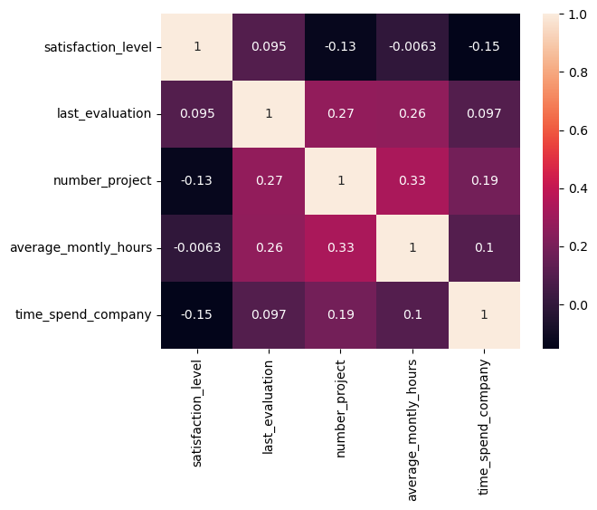

```python
sns.heatmap(hr_data[['satisfaction_level', 'last_evaluation', 'number_project', 'average_montly_hours', 'time_spend_company']].corr(), annot = True)
```

**Результат:**

- Наиболее скореллированные переменные: average_montly_hours и number_project: **0.33**
- ННаименее скоррелированные переменные average_montly_hours и satisfaction_level: **-0.0063**

# Задание 4

Рассчитайте сколько сотрудников работает в каждом департаменте.

```python
hr_data.groupby('department').size()
```

```
department
IT              976
RandD           694
accounting      621
hr              601
management      436
marketing       673
product_mng     686
sales          3239
support        1821
technical      2244
dtype: int64
```

# Задание 5

Показать распределение сотрудников по зарплатам.

```python
hr_data.salary.value_counts()
```

```
low       5740
medium    5261
high       990
Name: salary, dtype: int64
```

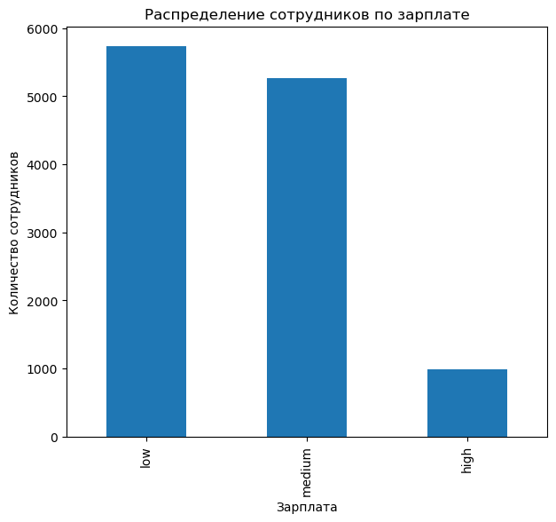

```python
plt.figure(figsize = (7, 6))
hr_data['salary'].value_counts().plot(kind = 'bar')
plt.xlabel('Зарплата')
plt.ylabel('Количество сотрудников')
plt.title('Распределение сотрудников по зарплате')
plt.show()
```

# Задание 6

Показать распределение сотрудников по зарплатам в каждом департаменте по отдельности

```python
hr_data.pivot_table(index='department', columns='salary', aggfunc='size')
```

| salary department | high | low | medium |
| --- | --- | --- | --- |
| IT | 71 | 476 | 429 |
| RandD | 47 | 322 | 325 |
| accounting | 63 | 296 | 262 |
| hr | 38 | 296 | 267 |
| management | 128 | 139 | 169 |
| marketing | 62 | 310 | 301 |
| product_mng | 52 | 343 | 291 |
| sales | 237 | 1553 | 1449 |
| support | 126 | 867 | 828 |
| technical | 166 | 1138 | 940 |

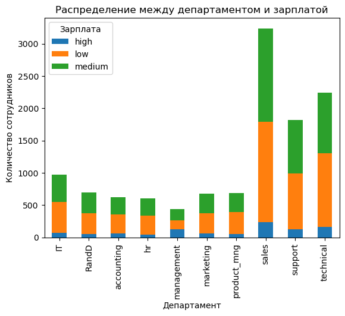

```python
plt.figure(figsize=(15, 10))
hr_data.groupby(['department', 'salary']).size().unstack().plot(kind='bar', stacked=True)
plt.xlabel('Департамент')
plt.ylabel('Количество сотрудников')
plt.title('Распределение между департаментом и зарплатой')
plt.legend(title='Зарплата')
plt.show()
```

# Задание 7

Проверить гипотезу, что сотрудники с высоким окладом проводят на работе больше времени, чем сотрудники с низким окладом

```
        average_montly_hours
salary
high              200.067677
low               200.439199
medium            200.587341
```

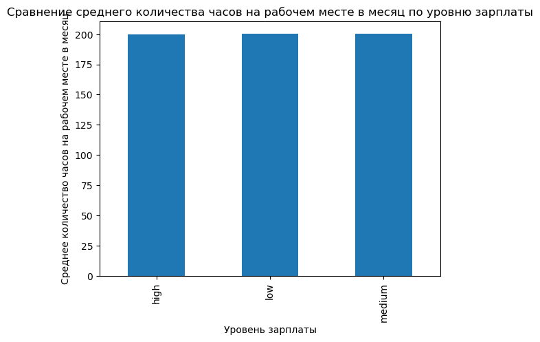

```python
pivot_table = hr_data.pivot_table(index='salary', values='average_montly_hours', aggfunc='mean')
print(pivot_table)

pivot_table.plot(kind='bar', legend=False)
plt.xlabel('Уровень зарплаты')
plt.ylabel('Среднее количество часов на рабочем месте в месяц')
plt.title('Сравнение среднего количества часов на рабочем месте в месяц по уровню зарплаты')
plt.show()
```

Визуально разницы в рабочих часах между сотрудниками с высоким и низким окладом нет, однако проверим это с помощью проверки гипотезы Предположим, что Н_0 = в среднем проведенное на работе время одинаково для всех работников

```python
salary_low = hr_data[hr_data['salary'] == 'low']['average_montly_hours']
salary_high = hr_data[hr_data['salary'] == 'high']['average_montly_hours']

result = stats.ttest_ind(salary_low, salary_high, equal_var=False)
a = 0.05
if (result.pvalue < a):
    print('Отвергаем нулевую гипотезу')
else:
    print('Нулевая гипотеза не отвергается')
```

```
Нулевая гипотеза не отвергается
```

# Задание 8

Рассчитать следующие показатели среди уволившихся и не уволившихся сотрудников (по отдельности):

- Доля сотрудников с повышением за последние 5 лет
- Средняя степень удовлетворенности
- Среднее количество проектов

```python
promoted_left = hr_data[hr_data['left'] == 1]['promotion_last_5years'].mean()
promoted_not_left = hr_data[hr_data['left'] == 0]['promotion_last_5years'].mean()
satisfaction_left = hr_data[hr_data['left'] == 1]['satisfaction_level'].mean()
satisfaction_not_left = hr_data[hr_data['left'] == 0]['satisfaction_level'].mean()
projects_left = hr_data[hr_data['left'] == 1]['number_project'].mean()
projects_not_left = hr_data[hr_data['left'] == 0]['number_project'].mean()
```

```python
results = pd.DataFrame(columns=['Повышение за последние 5 лет', 'Уровень удовлетворенности', 'Количество проектов'])
results.loc['Ушли'] = [promoted_left, satisfaction_left, projects_left]
results.loc['Не ушли'] = [promoted_not_left, satisfaction_not_left, projects_not_left]
results
```

|  | Повышение за последние 5 лет | Уровень удовлетворенности | Количество проектов |
| --- | --- | --- | --- |
| Ушли | 0.004018 | 0.440271 | 3.883476 |
| Не ушли | 0.019500 | 0.667365 | 3.786800 |

# Задание 9

Разделить данные на тестовую и обучающую выборки Построить модель LDA, предсказывающую уволился ли сотрудник на основе имеющихся факторов (кроме department и salary) Оценить качество модели на тестовой выборки

```python
# Разделение данных на признаки (X) и целевую переменную (y)
X = hr_data.drop(['left', 'department', 'salary'], axis=1)
y = hr_data['left']
```

```python
X_train, X_test, y_train, y_test = train_test_split(X, y, test_size=0.2, random_state=42)
```

```python
# Построение модели LDA
lda = LinearDiscriminantAnalysis()
lda.fit(X_train, y_train)

# Оценка качества модели на тестовой выборке
accuracy = lda.score(X_test, y_test)
print("Accuracy:", accuracy)
```

```
Accuracy: 0.830762817840767
```

# Задание 10

https://github.com/Natadelaer/netology_diploma